# MSDS6306CaseStudy

Priyanka Tilak

March 19, 2017

## Introduction to the Project

This document describes the Gross Domestic Product data and Educational data for 190 countries across the world. We are analyzing GDP of the countries, different income groups of these countries and their contribution in million US dollars of Gross domestic product in each country.

We have downloaded 2 data files, 1 for GDP data and Countries educational data from the following web sources:

GDP of 190 countries: https://d396qusza40orc.cloudfront.net/getdata%2Fdata%2FGDP.csv

Educational statistics of Different countries: https://d396qusza40orc.cloudfront.net/getdata%2Fdata%2FEDSTATS_Country.csv

#### Information about raw data files:

- Both the raw data files are in Comma separated format (csv)
- GDP file has NAs, missing heading, missing rows, content which is not very informative
- Education information data files has NAs
- Filtering required to perform analysis on these files

#### Objectives:

- Merge the data based on the country short code. How many of the IDs match?
- Sort the data frame in ascending order by GDP (so United States is last). What is the 13th country in the resulting data frame?
- What are the average GDP rankings for the “High income: OECD” and “High income: nonOECD” groups?
- Show the distribution of GDP value for all the countries and color plots by income group. Use ggplot2 to create your plot.
- Provide summary statistics of GDP by income groups.
- Cut the GDP ranking into 5 separate quantile groups. Make a table versus Income.Group. How many countries are Lower middle income but among the 38 nations with highest GDP?

To begin with we will first set up a working directory.

```r
#Set the present directory as working directory
setwd(".")
#view present working directory
getwd()
```

```
## [1] "C:/Personal/SMU/SAS/R/R_REPO/MSDS6306CaseStudy1"
```

Setting up the working directory and downloading data files from web resources

```r
#Downloading GDP file from the WEB URL
download.file("https://d396qusza40orc.cloudfront.net/getdata%2Fdata%2FGDP.csv",destfile = ".\\Data\\GDP.csv", mode = "w")

#Downloading Edstats_country file from the WEB URL
download.file("https://d396qusza40orc.cloudfront.net/getdata%2Fdata%2FEDSTATS_Country.csv",destfile = ".\\Data\\Edstats_Country.csv", mode= "w")

#Libraries Required
library(downloader)
library(plyr)
library(dplyr)
library(ggplot2)
library(sqldf)
```

#### Problems with Raw Data files

Raw data files required cleaning in order to move further for analysis and merging

- GDP data file has empty rows
- GDP data file has empty column
- GDP data file needs to have fix for column headings
- GDP data file has data for 190 countries and other geographical regions which are not country
- GDP for countries has NAs and missing value
- Education data for country has many columns which are not required for the analysis or objectives
- Education data for countries has NA’s and missing value

## Data Wrangling

To clean the raw data files in order to use it for merging and for analysis, Data Wrangling step is performed

```r
#read the Downloaded files in objects
GDP<-read.csv(".\\Data\\GDP.csv",sep=",",header=F, skip= 5)
Edstats_Country<-read.csv("C:\\Personal\\SMU\\SAS\\R\\R_REPO\\MSDS6306CaseStudy1\\Data\\Edstats_Country.csv",sep=",",header=T)

library(plyr)
#GDP data file cleanup\n
#giving new column names and ignoring empty rows for GDP table
colnames(GDP) <- c("CountryCode","Rank","Empty","CountryName","GDPA" )
keep_columns<-c("CountryCode","Rank","CountryName","GDPA")
GDP<-GDP[keep_columns]

# Calculating missing values and NAs before cleaning up GDP data
sum(is.na(GDP$CountryCode) | GDP$CountryCode=="")
```

```
## [1] 98
```

```r
sum(is.na(GDP$Rank) | GDP$Rank=="")
```

```
## [1] 132
```

```r
sum(is.na(GDP$GDPA) | GDP$GDPA =="")
```

```
## [1] 99
```

```r
#Cleaning GDP file data
GDP<-GDP[!(is.na(GDP$CountryCode) | GDP$CountryCode=="" | is.na(GDP$GDPA) | GDP$GDPA=="" | is.na(GDP$Rank) | GDP$Rank==""),]
#view first 5 rows of the dataframe
head(GDP)
```

```
##   CountryCode Rank    CountryName         GDPA
## 1         USA    1  United States  16,244,600
## 2         CHN    2          China   8,227,103
## 3         JPN    3          Japan   5,959,718
## 4         DEU    4        Germany   3,428,131
## 5         FRA    5         France   2,612,878
## 6         GBR    6 United Kingdom   2,471,784
```

```r
#Cleaning Edstats_Country data file
colnames(Edstats_Country)[1] <- "CountryCode"
colnames(Edstats_Country)[2] <- "LongName"
colnames(Edstats_Country)[3] <- "IncomeGroup"

# Calculating missing values and NAs before cleaning up Edstats_Country data
sum(is.na(Edstats_Country$CountryCode) | Edstats_Country$CountryCode=="")
```

```
## [1] 0
```

```r
sum(is.na(Edstats_Country$Income.Group) | Edstats_Country$Income.Group=="")
```

```
## [1] 0
```

```r
library(sqldf)
Edstats_Country<-sqldf("select Edstats_Country.CountryCode,Edstats_Country.LongName, Edstats_Country.IncomeGroup from Edstats_Country ")
#view first 5 rows of the dataframe
head(Edstats_Country)
```

```
##   CountryCode                     LongName          IncomeGroup
## 1         ABW                        Aruba High income: nonOECD
## 2         ADO      Principality of Andorra High income: nonOECD
## 3         AFG Islamic State of Afghanistan           Low income
## 4         AGO  People's Republic of Angola  Lower middle income
## 5         ALB          Republic of Albania  Upper middle income
## 6         ARE         United Arab Emirates High income: nonOECD
```

## Analysis

To perform the analysis on GDP of the countries and their income groups, both cleaned data files “GDP”" and Edstats_Country need to be merged

### Objective 1: Merge the data based on the country short code. How many of the IDs match?

Following is the Merged Table and its structure, which is merged table of GDP and Edstats_Country

```r
#merging 2 tables by CountryCode in to new data frame Merged_Table
Merged_Table<-merge(GDP,Edstats_Country, by="CountryCode")
#viewving first five records of the merged data frame "Merged_Table"
head(Merged_Table)
```

```
##   CountryCode Rank          CountryName      GDPA
## 1         ABW  161                Aruba    2,584
## 2         AFG  105          Afghanistan   20,497
## 3         AGO   60               Angola  114,147
## 4         ALB  125              Albania   12,648
## 5         ARE   32 United Arab Emirates  348,595
## 6         ARG   26            Argentina  475,502
##                       LongName          IncomeGroup
## 1                        Aruba High income: nonOECD
## 2 Islamic State of Afghanistan           Low income
## 3  People's Republic of Angola  Lower middle income
## 4          Republic of Albania  Upper middle income
## 5         United Arab Emirates High income: nonOECD
## 6           Argentine Republic  Upper middle income
```

```r
#removing blank and "," values in GDPA and Rank column and making it as numeric column
Merged_Table$GDPA <- as.numeric(gsub(",","", Merged_Table$GDPA))
Merged_Table$Rank <- as.numeric(gsub(",","", Merged_Table$Rank))
#structure of the Merged_Table
str(Merged_Table)
```

```
## 'data.frame':    189 obs. of  6 variables:
##  $ CountryCode: Factor w/ 229 levels "","ABW","ADO",..: 2 4 5 6 7 8 9 11 12 13 ...
##  $ Rank       : num  161 105 60 125 32 26 133 172 12 27 ...
##  $ CountryName: Factor w/ 229 levels "","  East Asia & Pacific",..: 20 11 16 12 216 18 19 17 21 22 ...
##  $ GDPA       : num  2584 20497 114147 12648 348595 ...
##  $ LongName   : Factor w/ 234 levels "American Samoa",..: 5 57 99 108 226 4 109 2 15 110 ...
##  $ IncomeGroup: Factor w/ 6 levels "","High income: nonOECD",..: 2 4 5 6 2 6 5 6 3 3 ...
```

### Objective 2: Sort the data frame in ascending order by GDP (so United States is last). What is the 13th country in the resulting data frame?

Following is the result of merging and sorting to get United State as a last country in the list, and 13th country in the list

```r
sortedMergeTable <- Merged_Table[ order(Merged_Table$GDPA), ]
#sorted merged table, "sortedMergeTable""
head(sortedMergeTable)
```

```
##     CountryCode Rank           CountryName GDPA
## 173         TUV  190                Tuvalu   40
## 92          KIR  189              Kiribati  175
## 113         MHL  188      Marshall Islands  182
## 137         PLW  187                 Palau  228
## 155         STP  186 São Tomé and Principe  263
## 59          FSM  185 Micronesia, Fed. Sts.  326
##                                         LongName         IncomeGroup
## 173                                       Tuvalu Lower middle income
## 92                          Republic of Kiribati Lower middle income
## 113             Republic of the Marshall Islands Lower middle income
## 137                            Republic of Palau Upper middle income
## 155 Democratic Republic of São Tomé and Principe Lower middle income
## 59                Federated States of Micronesia Lower middle income
```

```r
#to create output file
sortedMergeTable<-sortedMergeTable[(!(is.na(sortedMergeTable$IncomeGroup) |sortedMergeTable$IncomeGroup =="")),]
write.csv(sortedMergeTable, file = ".\\Data\\sortedMergeTable.csv")
head(sortedMergeTable)
```

```
##     CountryCode Rank           CountryName GDPA
## 173         TUV  190                Tuvalu   40
## 92          KIR  189              Kiribati  175
## 113         MHL  188      Marshall Islands  182
## 137         PLW  187                 Palau  228
## 155         STP  186 São Tomé and Principe  263
## 59          FSM  185 Micronesia, Fed. Sts.  326
##                                         LongName         IncomeGroup
## 173                                       Tuvalu Lower middle income
## 92                          Republic of Kiribati Lower middle income
## 113             Republic of the Marshall Islands Lower middle income
## 137                            Republic of Palau Upper middle income
## 155 Democratic Republic of São Tomé and Principe Lower middle income
## 59                Federated States of Micronesia Lower middle income
```

```r
#to view 13th country
sortedMergeTable[13,3]
```

```
## [1] St. Kitts and Nevis
## 229 Levels:    East Asia & Pacific   Euro area ... Zimbabwe
```

### Objective 3: What are the average GDP rankings for the High income: OECD and High income: nonOECD groups?

Average Ranking for the different Income group and their respective mean in column ‘X’

```r
library(dplyr)
AvgRanking<-aggregate(sortedMergeTable$Rank,list(sortedMergeTable$IncomeGroup),mean)
print(AvgRanking)
```

```
##                Group.1         x
## 1 High income: nonOECD  91.91304
## 2    High income: OECD  32.96667
## 3           Low income 133.72973
## 4  Lower middle income 107.70370
## 5  Upper middle income  92.13333
```

### Objective 4: Show the distribution of GDP value for all the countries and color plots by income group. Use ggplot2 to create your plot.

Bar chart representation of GDP values of the countries and their Income group Contributions

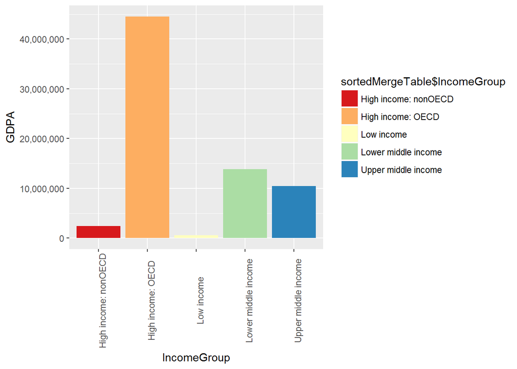

```r
library(ggplot2)
library(scales)
ggplot(sortedMergeTable,aes(x=IncomeGroup, y=GDPA,group_by(sortedMergeTable$IncomeGroup)))+ geom_bar(aes(fill=sortedMergeTable$IncomeGroup), stat = "identity") + scale_fill_brewer(palette = "Spectral") + theme( axis.text.x=element_text(angle=90)) +scale_y_continuous(labels = comma)
```

### Objective 5: Provide summary statistics of GDP by income groups

Summary Statistics of the complete merged data set for GDP

```r
library('dplyr')
#Provide summary statistics of GDP by income groups.
summary(sortedMergeTable$GDPA, by=sortedMergeTable$IncomeGroup)
```

```
##     Min.  1st Qu.   Median     Mean  3rd Qu.     Max.
##       40     6972    28240   379600   205800 16240000
```

Summary Statistics of the complete merged data set for GDP for Lower Income group

```r
#Statistics for Lower Income group
lowerIncome<-sortedMergeTable[sortedMergeTable$IncomeGroup=="Low income",]
print(summary(lowerIncome$GDPA))
```

```
##    Min. 1st Qu.  Median    Mean 3rd Qu.    Max.
##     596    3814    7843   14410   17200  116400
```

Summary Statistics of the complete merged data set for GDP for Lower Middle Income group

```r
#Statistics for Lower Middle Income group
lowerMiddleIncome<-sortedMergeTable[sortedMergeTable$IncomeGroup=="Lower middle income",]
print(summary(lowerMiddleIncome$GDPA))
```

```
##    Min. 1st Qu.  Median    Mean 3rd Qu.    Max.
##      40    2549   24270  256700   81450 8227000
```

Summary Statistics of the complete merged data set for GDP for Upper Middle Income group

```r
#Statistics for Upper Middle Income group
upperMiddleIncome<-sortedMergeTable[sortedMergeTable$IncomeGroup=="Upper middle income",]
print(summary(upperMiddleIncome$GDPA))
```

```
##    Min. 1st Qu.  Median    Mean 3rd Qu.    Max.
##     228    9613   42940  231800  205800 2253000
```

Summary Statistics of the complete merged data set for GDP for High Income group

```r
#Statistics for High Income group
highIncomeOECD<-sortedMergeTable[sortedMergeTable$IncomeGroup=="High income: OECD",]
print(summary(highIncomeOECD$GDPA))
```

```
##     Min.  1st Qu.   Median     Mean  3rd Qu.     Max.
##    13580   211100   486500  1484000  1480000 16240000
```

Summary Statistics of the complete merged data set for GDP for High Income group

```r
#Statistics for High Income Income group
highIncomeNonOECD<-sortedMergeTable[sortedMergeTable$IncomeGroup=="High income: nonOECD",]
summary(highIncomeNonOECD$GDPA)
```

```
##    Min. 1st Qu.  Median    Mean 3rd Qu.    Max.
##    2584   12840   28370  104300  131200  711000
```

#### Objective 6: Cut the GDP ranking into 5 separate quantile groups. Make a table versus Income.Group. How many countries are Lower middle income but among the 38 nations with highest GDP?

```r
quantileGrps <-quantile(sortedMergeTable$Rank, probs=seq(0,1,0.2),na.rm=TRUE)
print(quantileGrps)
```

```
##    0%   20%   40%   60%   80%  100%
##   1.0  38.6  76.2 113.8 152.4 190.0
```

```r
gdpQuantile <- cut(sortedMergeTable$Rank, breaks = quantileGrps)
#print(gdpQuantile)
sortedMergeTable$RankGroup <- gdpQuantile
tableIncGrpVsRnkGrp <- table(sortedMergeTable$IncomeGroup, sortedMergeTable$RankGroup)
tableIncGrpVsRnkGrp
```

```
##
##                        (1,38.6] (38.6,76.2] (76.2,114] (114,152] (152,190]
##                               0           0          0         0         0
##   High income: nonOECD        4           5          8         4         2
##   High income: OECD          17          10          1         1         0
##   Low income                  0           1          9        16        11
##   Lower middle income         5          13         11         9        16
##   Upper middle income        11           9          8         8         9
```

Countries count which are lower middle income but among the 38 nations with the highest GDP

```r
lower_mid_inc_count <-sqldf("select count(*) from sortedMergeTable where IncomeGroup=='Lower middle income' and  Rank <39")
print("Countries count which are lower middle income but among the 38 nations with the highest GDP")
```

```
## [1] "Countries count which are lower middle income but among the 38 nations with the highest GDP"
```

```r
print(lower_mid_inc_count)
```

```
##   count(*)
## 1        5
```

## References

- https://www.rstudio.com/wp-content/uploads/2015/02/rmarkdown-cheatsheet.pdf
- https://learnr.wordpress.com/2009/04/15/ggplot2-qualitative-colour-palettes/
- https://www.r-bloggers.com
- https://stackoverflow.com
- http://www.statmethods.net
- https://www.r-project.org